# Курс по машинному обучению, ВМК МГУ

# Основы numpy + matplotlib + pandas

## Подготовка рабочей среды

Сначала установим нужные нам версии библиотек. Мы гарантируем, что в данных версиях задание будет корректно отрабатывать.

После установки нужных версий нажмите на кнопку Restart runtime, которая появится в следующей ячейке после завершения ее выполнения.

После перезапуска (restart runtime) устанавливать библиотеки еще раз не нужно, достаточно проверить, что установилась их новая версия.

На скачивание файла и установку понадобится не более 5 минут.

**Важно!** Устанавливать нужные версии нужно каждый раз, когда создается новый рантайм. Например, если вы 2 часа подряд делаете это задание, то подготовить библиотеки достаточно 1 раз. Но если вы, например, начали в понедельник, затем закрыли/выключили ноутбук, то при продолжении в среду, вам нужно будет запустить рантайм заново и следовательно заново установить библиотеки.

**Важно!** Если вы предпочитаете делать практические задания на своем личном ноутбуке, то предлагаем вам завести виртуальное окружение и установить в нем библиотеки из файла requirements.txt по ссылке https://drive.google.com/file/d/1br9tHmdccGVzpk0svXNmHxVMh_OF2oZR/view?usp=sharing В таком случае виртуальное окружение достаточно настроить всего один раз.

```python
# !!! Данный блок будет работать только в Google-Colab !!!
! gdown 1br9tHmdccGVzpk0svXNmHxVMh_OF2oZR
! pip install -r /content/requirements.txt
```

```
Downloading...
From: https://drive.google.com/uc?id=1br9tHmdccGVzpk0svXNmHxVMh_OF2oZR
To: /content/requirements.txt
100% 328/328 [00:00<00:00, 478kB/s]
```

Проверим версию библиотеки:

```python
import xgboost
assert(xgboost.__version__ == '1.6.2')
```

Теперь можно приступать к выполнению задания! :)

# О задании

Задание состоит из трех частей, посвященных работе с табличными данными с помощью библиотеки **pandas**, визуализации с помощью библиотек **matplotlib**, **seaborn**, **plotly** и векторным вычислениям с помощью библиотеки **numpy**. Вам предлагается выполнить несколько заданий.

# Часть 1. Pandas

В этой части мы познакомимся с библиотекой **pandas**. **Pandas** — удобная библиотека для работы с табличными данными в Python, если данных не слишком много и они помещаются в оперативную память вашего компьютера.

С помощью встроенных инструментов **pandas** можно легко:

- считывать табличные данные (в форматах csv, json, xlsx)
- представлять собственные данные в виде таблиц и сохранять их
- считать статистики
- визулизировать данные
- производить обработку данных
- и много всего еще...

Основные объекты в **pandas**:

- **Series** (серия) — одномерная структура данных, в которой каждый элемент имеет свой индекс.
- **DataFrame** (датафрейм) - табличная структура данных, представляющая собой таблицу с именованными колонками различных типов и индексами строк.

Полезные материалы:

1. [Документация](http://pandas.pydata.org/pandas-docs/stable/index.html)
2. [Pandas за 10 минут из официального руководства](http://pandas.pydata.org/pandas-docs/stable/10min.html)
3. [Примеры использования функционала](http://nbviewer.jupyter.org/github/justmarkham/pandas-videos/blob/master/pandas.ipynb)

Далее потребуется выполнить несколько небольших заданий, покрывающих базовый функционал библиотеки.

#### Важно!

- **Все задания в этой части оцениваются по системе кросс-рецензирования.**
- **Многие из заданий можно выполнить несколькими способами. Не существуют единственно верного, но попробуйте максимально задействовать арсенал pandas и ориентируйтесь на простоту и понятность вашего кода. Не забывайте, что можно гуглить и что-то искать на stackoverflow, например.**
- **Везде, где в формулровке задания есть какой-либо вопрос (или просьба вывода), необходимо прописать ответ в ячейку (код или markdown).**
- **Наличие кода решения обязательно. Письменные ответы на вопросы без сопутствующего кода оцениваются в 0 баллов.**
- **Для удобства поиска вопросов, на которые от вас просят ответа, мы пометили их знаком (?)**

```python
import pandas as pd
```

```python
!gdown 1sA-fqJb1WxhS_jaYDcIwXWa_b8b2oZJ6
```

```
Downloading...
From: https://drive.google.com/uc?id=1sA-fqJb1WxhS_jaYDcIwXWa_b8b2oZJ6
To: /content/youtube_trending_mediterranean.csv
100% 6.22M/6.22M [00:00<00:00, 154MB/s]
```

#### Задание 1 (0.4 балла).

- **(0.2 балла)** Откройте файл с таблицей и выведите последние 5 строк.
- **(0.2 балла)** **(?)** Посмотрите на данные и скажите, что они из себя представляют, сколько в таблице строк и столбцов?

Полезные материалы: https://pandas.pydata.org/pandas-docs/stable/getting_started/intro_tutorials/02_read_write.html

```python
df = pd.read_csv('/content/youtube_trending_mediterranean.csv')
df.tail(5)
```

|  | country | video_id | title | publishedAt | channelId | channelTitle | categoryId | trending_date | tags | view_count | comment_count | thumbnail_link | comments_disabled | ratings_disabled | description |
| --- | --- | --- | --- | --- | --- | --- | --- | --- | --- | --- | --- | --- | --- | --- | --- |
| 3216 | NaN | eB-A1Y0Dswc | Thank you for watching | 2022-07-05T21:18:33Z | UCS5tt2z_DFvG7-39J3aE-bQ | Life of Boris | 22 | 22.11.07 | lifeofboris\|life of boris\|english subtitles\|ye... | 864216 | 14431 | https://i.ytimg.com/vi/eB-A1Y0Dswc/default.jpg | False | True | New channel: https://www.youtube.com/channel/U... |
| 3217 | NaN | KJGTtzccOHU | Pokemon Emerald but every battle is extremely ... | 2022-07-05T01:55:10Z | UC0VVYtw21rg2cokUystu2Dw | SmallAnt | 20 | 22.11.07 | pokemon\|smallant\|smallant1\|challenge\|pokemon c... | 1311698 | 1232 | https://i.ytimg.com/vi/KJGTtzccOHU/default.jpg | False | True | Pokemon emerald but every battle is a 1v2You s... |
| 3218 | NaN | be8mqaTi_DI | Victor Cibrian x Fuerza Regida x Luis R Conriq... | 2022-07-04T21:00:36Z | UC648rgJOboZlgcDbW00vTSA | Rancho Humilde | 10 | 22.11.07 | Rancho Humilde\|Legado 7\|El De La Guitarra\|Fuer... | 2256933 | 597 | https://i.ytimg.com/vi/be8mqaTi_DI/default.jpg | False | True | SuscrÃbete: https://Rancho.lnk.to/RHYoutube\r... |
| 3219 | NaN | 14aYHc7ybu0 | WE STAYED AT A 1 STAR HOTEL FOR 24 HOURS \| coc... | 2022-07-05T13:40:04Z | UCSGoIq_tVESqNYF1Re-zn1Q | HJ Evelyn | 24 | 22.11.07 | hjevelyn\|Evelyn ha\|Emily ha\|erica ha\|korean si... | 922668 | 2951 | https://i.ytimg.com/vi/14aYHc7ybu0/default.jpg | False | True | never again ahaha.... CHECK OUT OUR MERCH: htt... |
| 3220 | NaN | mQ9eFI13NCQ | I 100%'d Cuphead: The Delicious Last Course, H... | 2022-07-04T16:04:33Z | UCRgzckrm1Svf-Y_dIWsTPTg | The Andrew Collette Show | 20 | 22.11.07 | cuphead\|cuphead dlc\|cuphead the delicious last... | 1176289 | 620 | https://i.ytimg.com/vi/mQ9eFI13NCQ/default.jpg | False | True | My Cuphead: The Delicious Last Course Let's Pl... |

```python
df.info()
```

```
<class 'pandas.core.frame.DataFrame'>
RangeIndex: 3221 entries, 0 to 3220
Data columns (total 15 columns):
 #   Column             Non-Null Count  Dtype
---  ------             --------------  -----
 0   country            3021 non-null   object
 1   video_id           3221 non-null   object
 2   title              3221 non-null   object
 3   publishedAt        3221 non-null   object
 4   channelId          3221 non-null   object
 5   channelTitle       3221 non-null   object
 6   categoryId         3221 non-null   int64
 7   trending_date      3221 non-null   object
 8   tags               3221 non-null   object
 9   view_count         3221 non-null   int64
 10  comment_count      3221 non-null   int64
 11  thumbnail_link     3221 non-null   object
 12  comments_disabled  3221 non-null   bool
 13  ratings_disabled   3221 non-null   bool
 14  description        3090 non-null   object
dtypes: bool(2), int64(3), object(10)
memory usage: 333.5+ KB
```

**Ответ**: Данные о видеороликах, 3221 строк, 15 столбцов

#### Задание 2 (0.6 балла).

Ответьте на вопросы:

- **(0.2 балла)** **(?)** Для скольких стран есть информация о видеороликах в таблице (включая None)? (колонка country)
- **(0.2 балла)** **(?)** Сколько есть видеороликов c разрешенными и запрещенными комментариями? (колонка comments_disabled). Под видеороликом считаем 1 запись в таблице.
- **(0.2 балла)** **(?)** Какое максимальное число просмотров у видеороликов, попавших в таблицу? (колонка view_count)

Базовый функционал, необxодимый для решения, можно найти [здесь](https://pandas.pydata.org/pandas-docs/stable/user_guide/basics.html).

```python
df['country'].value_counts(dropna = False).count()
```

```
20
```

```python
df['comments_disabled'].value_counts(dropna = False)
```

```
False    3193
True       28
Name: comments_disabled, dtype: int64
```

```python
df['view_count'].max()
```

```
123034293
```

**Ответ**:

1. 20
2. С разрешёнными 3193, с запрещёнными 28
3. 123034293

#### Задание 3 (0.5 балла)

**(0.2 балл)** **(?)** Есть ли в данных пропуски? В каких колонках?

Про работу с пропущенными значениями можно прочитать [здесь](https://pandas.pydata.org/pandas-docs/stable/user_guide/missing_data.html).

```python
df.isna().sum()
```

```
country              200
video_id               0
title                  0
publishedAt            0
channelId              0
channelTitle           0
categoryId             0
trending_date          0
tags                   0
view_count             0
comment_count          0
thumbnail_link         0
comments_disabled      0
ratings_disabled       0
description          131
dtype: int64
```

**Ответ**: Пропуски в колонках country и description

**(0.3 балла)** Заполните пропуски пустой строкой для текстовых колонок, и удалите строки с пропусками для колонок с категориальными значениями.

Подсказка: Значения категориальной переменной определяют факт принадлежности к какой-то категории, категорий при этом должно быть ограниченное кол-во сильно меньшее размера датасета.

**Внимание!** Для проверки корректности выведите кол-во пропусков во всех столбцах и общее кол-во строк в таблице - должна быть 3021 запись. Ошибка при удалении строк может привести к неправильному выполнению следующих заданий.

```python
df = df.dropna(subset = ['country'])
df['description'] = df['description'].fillna("")
df.shape
```

```
(3021, 15)
```

#### Задание 4 (0.6 балла).

Посмотрите на колонку publishedAt

- **(0.1 балла) (?)** Какого она типа?
- **(0.2 балла)** Измените тип колонки на datetime. Покажите, что после изменения колонка действительно имеет тип datetime.
- **(0.3 балла) (?)** В какой месяц было добавлено больше всего видеороликов?

Полезные материалы: https://pandas.pydata.org/pandas-docs/stable/user_guide/timeseries.html

```python
df.dtypes
```

```
country              object
video_id             object
title                object
publishedAt          object
channelId            object
channelTitle         object
categoryId            int64
trending_date        object
tags                 object
view_count            int64
comment_count         int64
thumbnail_link       object
comments_disabled      bool
ratings_disabled       bool
description          object
dtype: object
```

```python
df['publishedAt'] = df['publishedAt'].astype('datetime64')
```

```python
df.dtypes
```

```
country                      object
video_id                     object
title                        object
publishedAt          datetime64[ns]
channelId                    object
channelTitle                 object
categoryId                    int64
trending_date                object
tags                         object
view_count                    int64
comment_count                 int64
thumbnail_link               object
comments_disabled              bool
ratings_disabled               bool
description                  object
dtype: object
```

```python
df['publishedAt'].dt.month.value_counts()
```

```
7    1955
6    1066
Name: publishedAt, dtype: int64
```

**Ответ**:

1. object
2. 7 (Июль)

#### Задание 5 (0.7 баллов).

Посмотрите на колонку description.

- **(0.2 балла)** Переведите строки в нижний регистр и обрежьте ненужные пробелы справа и слева.
- **(0.3 балла)** Замените url-адреса в описаниях на специальный тэг \<URL>.
- **(0.2 балла)** Выведите полностью description для видеоролика с video_id = 'Oxexirlmdig'.

Полезные материалы:

- Про работу с текстовыми данными в pandas: https://pandas.pydata.org/pandas-docs/stable/user_guide/text.html

```python
df['description'] = df['description'].apply(lambda x: x.lower().strip())
df['description']
```

```
0       stream or download now ''katile'' ð https:/...
1       the official video for gajde.stream/download g...
2       stream or download âam/pmâ here ð§ https...
3       bzzz entertainment - https://lnk.to/bzzzstream...
4       stream âtequilaâ:https://taynaxazet.lnk.to...
                              ...
3016    fenerbahã§e hazä±rlä±k maã§ä±nda mol fehervar'...
3017    download now!! âºâº https://supr.cl/2k62czgb...
3018    gã¶rã¼lmemiå bir ekonomik kriz geliyor,ekonom...
3019    tozluyaka 2. bã¶lã¼m 2. fragmanä±åans bile yo...
3020    onur tuärul, mustafa demirtaå, metin karabaå...
Name: description, Length: 3021, dtype: object
```

```python
pattern = r'http\S+'
df['description'] = df['description'].apply(lambda x: x.replace(pattern, '<URL>'))
```

```python
df[df.video_id == 'Oxexirlmdig']['description']
```

```
12    music line & lyrics : ghetto geasy & majkmusic...
Name: description, dtype: object
```

#### Задание 6 (0.4 балла).

**(0.4 балла)** **(?)** Какие 5 каналов в Италии (country='IT') опубликовали ролики с наибольшим числом комментариев (колонка comment_count)? В качестве ответа привидите названия (колонка channelTitle) нужных каналов, отcортированных по убыванию кол-ва просмотров (колонка view_count) самых популярных видеороликов (по кол-ву комментариев).

Для решения воспользуйтесь функцией [sort_values](https://pandas.pydata.org/pandas-docs/stable/reference/api/pandas.DataFrame.sort_values.html).

```python
df[df.country == 'IT'].sort_values('comment_count', ascending = False).head(5).sort_values('view_count', ascending = False)['channelTitle']
```

```
1599            SMTOWN
1597    Fleeting Films
1649         FORMULA 1
1612          TiniVEVO
1632       PlayStation
Name: channelTitle, dtype: object
```

**Ответ**:

1. SMTOWN
2. Fleeting Films
3. FORMULA 1
4. TiniVEVO
5. PlayStation

#### Задание 7 (0.4 балла).

**(0.4 балла)** **(?)** Какой видеоролик был опубликован в наибольшем кол-ве стран? В качестве ответа привeдите название видеоролика (колонка title).

Для решения могут помочь функции [groupby](https://pandas.pydata.org/pandas-docs/stable/reference/api/pandas.DataFrame.groupby.html) и [sort_values](https://pandas.pydata.org/pandas-docs/stable/reference/api/pandas.DataFrame.sort_values.html).

```python
df.groupby(['title', 'country']).count().groupby('title').count().sort_values('video_id', ascending = False)['video_id'].head()
```

```
title
Race Highlights | 2022 British Grand Prix                                    17
j-hope 'MORE' Official MV                                                    14
God of War RagnarÃ¶k - Father and Son Cinematic Trailer | PS5 & PS4 Games    14
World's Fastest Car!                                                         14
Charlie Puth - Left And Right (feat. Jung Kook of BTS) [Official Video]      12
Name: video_id, dtype: int64
```

**Ответ**: Race Highlights | 2022 British Grand Prix

#### Задание 8 (0.4 балла).

**(0.4 балла)** **(?)** Какое максимальное число просмотров (колонка view_count) у видеороликов, выпущенных во Франции или Италии (в колонке country значениe FR или IT) в июле (колонка publishedAt)?

Необходимо придумать решение в одну строку, используя для выбора строк несколько условий, объединенных с помощью | вместо or, & вместо and и ~ вместо not, а также используя функцию [isin](https://pandas.pydata.org/pandas-docs/stable/reference/api/pandas.DataFrame.isin.html).

```python
df[(df['country'].isin(['FR', 'IT'])) & (df['publishedAt'].dt.month == 7)]['view_count'].max()
```

```
82864422
```

**Ответ**: 82864422

#### Задание 9 (0.5 балла).

- **(0.1 балла)** **(?)** Посмотрите на названия каналов из 17 категории (колонка categoryId). Как вы думаете, что это за категория?
- **(0.4 балла)** Предположим, что была допущена ошибка, и все видеоролики из 17 категории, относятся к 16 категории. Исправьте нужные значения в колонке categoryId, после чего выведите все уникальные категории.

Обратите внимание, что при выборе полей с помощью оператора индексирования [] возвращается копия выбранных значений. При попытке присвоить таким образом новые значения для некоторых полей таблицы, будет выдано предупреждение. Более надежный способ - использовать операторы loc и iloc. Подробнее про индексацию и выбор строк можно прочитать [здесь](https://pandas.pydata.org/pandas-docs/stable/user_guide/indexing.html).

```python
df.loc[df['categoryId'] == 17, 'categoryId'] = 16
df['categoryId'].unique()
```

```
array([24, 10,  1, 15, 22, 23, 27, 16, 20, 26, 25,  2, 19, 28])
```

```python
df[df.categoryId == 17].channelTitle
```

[output not shown]

**Ответ**: Спорт

#### Задание 10 (1 балл).

Посмотрите на колонку tags.

- **(0.2 балла)** **(?)** Замените строки со значением '[none]' на пустую строку.
- **(0.8 балла)** **(?)** Какой самый популярный тэг? Обратите внимание, что у каждого видеоролика может быть более 1 тэга.

Для предобработки данных могут помочь функции [apply](https://pandas.pydata.org/pandas-docs/stable/reference/api/pandas.DataFrame.apply.html) и [explode](https://pandas.pydata.org/pandas-docs/stable/reference/api/pandas.DataFrame.explode.html).

```python
df['tags'].replace('[none]','').apply(lambda x: x.lower().strip()).apply(lambda x: x.split('|')).explode().value_counts()
```

```
                                     590
challenge                            133
øªøø¯ù                             127
øªøø¯ùø§øª                         124
minecraft                             74
                                    ...
league                                 1
star guardian                          1
star guardian 2022                     1
star guardian cinematic                1
tozluyaka 2. bã¶lã¼m 2. fragmanä±      1
Name: tags, Length: 18309, dtype: int64
```

**Ответ**: challenge

# Часть 2. Визуализация данных

### Оформление графиков

Важно, чтобы все графики выглядели опрятно и соответствовали следующим правилам:

- должно быть название (plt.title) графика;
- на графиках должны быть подписаны оси (plt.xlabel, plt.ylabel);
- должны быть подписаны единицы измерения (если это возможно);
- все названия должны быть понятны любому человеку, знакомому с терминологией, без заглядывания в код;
- подписи тиков на осях не должны сливаться как на одной оси, так и между ними;
- если изображено несколько сущностей на одном холсте (например несколько функций), то необходима поясняющая легенда (plt.legend);
- все линии на графиках должны быть чётко видны (нет похожих цветов или цветов, сливающихся с фоном);
- если отображена величина, имеющая очевидный диапазон значений (например, проценты могут быть от 0 до 100), то желательно масштабировать ось на весь диапазон значений (исключением является случай, когда вам необходимо показать малое отличие, которое незаметно в таких масштабах);
- графики должны быть не супер-микро и не супер-макро по размерам, так, чтобы можно было увидеть все, что нужно.
- при необходимости улучшения наглядности графиков, можно пользоваться логарифмической шкалой по осям x/y.

```python
import matplotlib
import matplotlib.pyplot as plt

#отображение графиков в ноутбуке
%matplotlib inline

#для четкой прорисовки графиков
#%config InlineBackend.figure_format = 'svg'
```

```python
import seaborn as sns
```

### Важно!

- **Все задания в этой части оцениваются по системе кросс-рецензирования.**
- **Проверьте, что при конвертации в html формат все графики остаются видны. Это нужно для дальнейшей проверки в проверяющей системе.**
- **При решении заданий вы можете воспользоваться любыми средствами для визуализации.**
- **Все графики должны выглядеть опрятно и соответствовать правилам, перечисленным в начале Части 2. В случае несоответствия хотя бы 3 пунктам оценка снижается на 0.5 балла.**

### Задание 1 (1.5 балла).

Постройте график (line plot) зависимости кол-ва выпущенных роликов от даты публикации.

Обратите внимание, что один и тот же ролик может быть опубликован в нескольких странах, и ему может соответствовать несколько строк в таблице. На графике необходимо учесть каждый ролик только 1 раз.

```python
df_plt1 = df[['video_id', 'publishedAt', 'title']]
df_plt1
```

|  | video_id | publishedAt | title |
| --- | --- | --- | --- |
| 0 | hxWSp-8jJuo | 2022-07-07 22:00:12 | DON XHONI - KATILE |
| 1 | MnrC9mk2H1o | 2022-06-30 22:00:11 | Dhurata Dora x Elvana Gjata - GAJDE (Official ... |
| 2 | 5Ql-G0dTqC0 | 2022-07-02 22:00:11 | KIDA x BUTRINT IMERI - AM/PM |
| 3 | oUdY0qSavvY | 2022-07-07 22:00:12 | Dafina Zeqiri - Malli |
| 4 | I4ZSvYLnOcQ | 2022-06-30 18:00:26 | Tayna x Azet - Tequila |
| ... | ... | ... | ... |
| 3016 | 2bvhzLli-Aw | 2022-07-05 18:46:34 | Fenerbahçe 3-0 Mol Fehervar \| HazÄ±rlÄ±k MaçÄ± |
| 3017 | imjlTtCxkkk | 2022-07-04 09:00:09 | Brawl Stars Season 13! - #DeepSeaBrawl |
| 3018 | rdAhWgxtteY | 2022-07-03 20:00:18 | GörülmemiÅ Bir Ekonomik Kriz Geliyor- Düny... |
| 3019 | FROtCry4nLw | 2022-07-01 20:47:38 | Tozluyaka 2. Bölüm 2. FragmanÄ± |
| 3020 | cwD6jnfIi9A | 2022-07-06 17:09:00 | FB, GS, BJK ve TS'de Son GeliÅmeler \| Onur & ... |

3021 rows × 3 columns

```python
df_plt1['publishedAt'] = df_plt1['publishedAt'].astype('datetime64')
df_plt1['publishedAt'] = df_plt1['publishedAt'].dt.date
df_plt1
```

|  | video_id | publishedAt | title |
| --- | --- | --- | --- |
| 0 | hxWSp-8jJuo | 2022-07-07 | DON XHONI - KATILE |
| 1 | MnrC9mk2H1o | 2022-06-30 | Dhurata Dora x Elvana Gjata - GAJDE (Official ... |
| 2 | 5Ql-G0dTqC0 | 2022-07-02 | KIDA x BUTRINT IMERI - AM/PM |
| 3 | oUdY0qSavvY | 2022-07-07 | Dafina Zeqiri - Malli |
| 4 | I4ZSvYLnOcQ | 2022-06-30 | Tayna x Azet - Tequila |
| ... | ... | ... | ... |
| 3016 | 2bvhzLli-Aw | 2022-07-05 | Fenerbahçe 3-0 Mol Fehervar \| HazÄ±rlÄ±k MaçÄ± |
| 3017 | imjlTtCxkkk | 2022-07-04 | Brawl Stars Season 13! - #DeepSeaBrawl |
| 3018 | rdAhWgxtteY | 2022-07-03 | GörülmemiÅ Bir Ekonomik Kriz Geliyor- Düny... |
| 3019 | FROtCry4nLw | 2022-07-01 | Tozluyaka 2. Bölüm 2. FragmanÄ± |
| 3020 | cwD6jnfIi9A | 2022-07-06 | FB, GS, BJK ve TS'de Son GeliÅmeler \| Onur & ... |

3021 rows × 3 columns

```python
df_plt1 = df_plt1.groupby(['video_id', 'publishedAt']).count().groupby('publishedAt').count()
df_plt1
```

| publishedAt | title |
| --- | --- |
| 2022-06-04 | 4 |
| 2022-06-05 | 4 |
| 2022-06-06 | 6 |
| 2022-06-07 | 6 |
| 2022-06-08 | 9 |
| 2022-06-09 | 8 |
| 2022-06-10 | 12 |
| 2022-06-11 | 7 |
| 2022-06-12 | 5 |
| 2022-06-13 | 11 |
| 2022-06-14 | 18 |
| 2022-06-15 | 15 |
| 2022-06-16 | 28 |
| 2022-06-17 | 17 |
| 2022-06-18 | 14 |
| 2022-06-19 | 9 |
| 2022-06-20 | 16 |
| 2022-06-21 | 29 |
| 2022-06-22 | 23 |
| 2022-06-23 | 28 |
| 2022-06-24 | 22 |
| 2022-06-25 | 30 |
| 2022-06-26 | 31 |
| 2022-06-27 | 33 |
| 2022-06-28 | 41 |
| 2022-06-29 | 44 |
| 2022-06-30 | 68 |
| 2022-07-01 | 61 |
| 2022-07-02 | 59 |
| 2022-07-03 | 73 |
| 2022-07-04 | 80 |
| 2022-07-05 | 121 |
| 2022-07-06 | 157 |
| 2022-07-07 | 173 |
| 2022-07-08 | 146 |
| 2022-07-09 | 107 |
| 2022-07-10 | 35 |

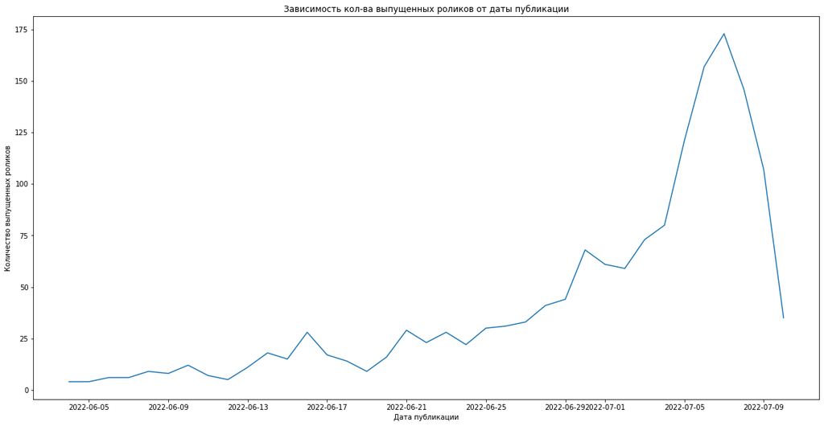

```python
plt.figure(figsize=(20,10))
plt.title('Зависимость кол-ва выпущенных роликов от даты публикации')
sns.lineplot(df_plt1, x = "publishedAt", y = "title")
plt.xlabel('Дата публикации')
plt.ylabel('Количество выпущенных роликов')
plt.show()
```

### Задание 2 (1.5 балла).

Постройте диаграмму (bar plot) кол-ва опубликованных роликов в зависимости от страны.

```python
df_plt2 = df[['video_id', 'country']]
df_plt2
```

|  | video_id | country |
| --- | --- | --- |
| 0 | hxWSp-8jJuo | AL |
| 1 | MnrC9mk2H1o | AL |
| 2 | 5Ql-G0dTqC0 | AL |
| 3 | oUdY0qSavvY | AL |
| 4 | I4ZSvYLnOcQ | AL |
| ... | ... | ... |
| 3016 | 2bvhzLli-Aw | TR |
| 3017 | imjlTtCxkkk | TR |
| 3018 | rdAhWgxtteY | TR |
| 3019 | FROtCry4nLw | TR |
| 3020 | cwD6jnfIi9A | TR |

3021 rows × 2 columns

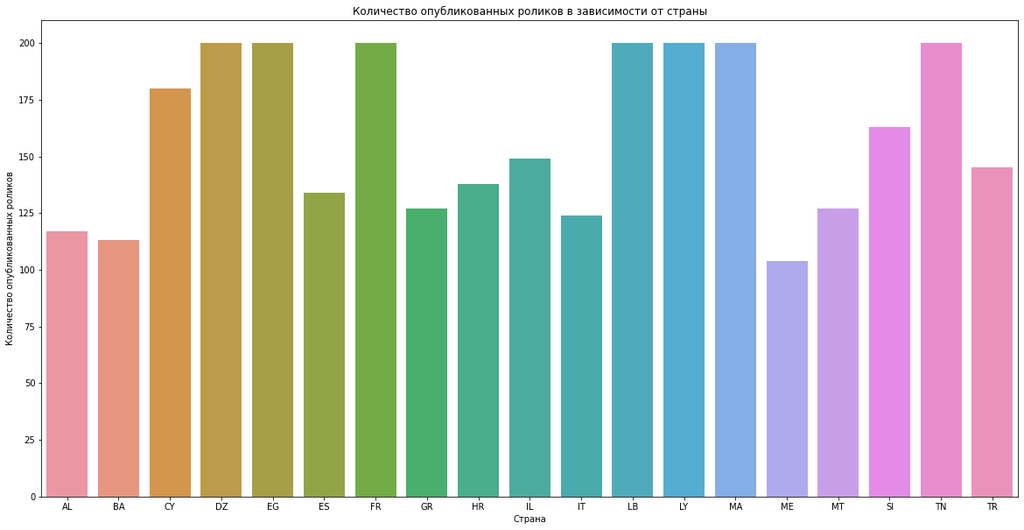

```python
plt.figure(figsize=(20,10))
plt.title('Количество опубликованных роликов в зависимости от страны')
sns.countplot(x = df_plt2['country'])
plt.xlabel('Страна')
plt.ylabel('Количество опубликованных роликов')
plt.show()
```

### Задание 3 (1.5 балла).

Постройте график (scatter plot) зависимости кол-ва комментариев для ролика от кол-ва просмотров для роликов во Франции (country='FR'). На графике не нужно учитывать ролики с отключенными комментариями (comments_disabled=True). Какой характер зависмости получился?

```python
df_plt3 = df[['country', 'video_id', 'view_count', 'comment_count', 'comments_disabled']]
df_plt3 = df_plt3[(df_plt3['country'] == 'FR') & (df_plt3['comments_disabled'] != True)]
df_plt3
```

|  | country | video_id | view_count | comment_count | comments_disabled |
| --- | --- | --- | --- | --- | --- |
| 944 | FR | P7vcGR8UjBY | 3236898 | 24702 | False |
| 945 | FR | 2aDVtZH7WvU | 859315 | 2024 | False |
| 946 | FR | 1UuS2rQraUg | 280124 | 581 | False |
| 947 | FR | h6u69XNFlOw | 189015 | 298 | False |
| 948 | FR | UvW2HD8ienc | 692939 | 1434 | False |
| ... | ... | ... | ... | ... | ... |
| 1139 | FR | S6gksDZ0Gwg | 171758 | 611 | False |
| 1140 | FR | raHLFg6bkNI | 1100514 | 2949 | False |
| 1141 | FR | WwXCzCIhhNk | 258106 | 229 | False |
| 1142 | FR | P4sTrntDqhw | 649221 | 563 | False |
| 1143 | FR | f7RCPUXAP8w | 40233 | 123 | False |

200 rows × 5 columns

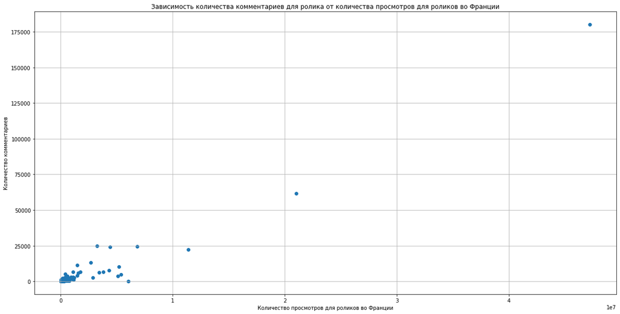

```python
plt.figure(figsize=(20,10))
plt.title('Зависимость количества комментариев для ролика от количества просмотров для роликов во Франции')
x = list()
plt.scatter(x = df_plt3['view_count'], y = df_plt3['comment_count'])
plt.ylabel('Количество комментариев')
plt.xlabel('Количество просмотров для роликов во Франции')
plt.grid(True)
plt.show()
```

Выбросы плохо влияют на читабельность

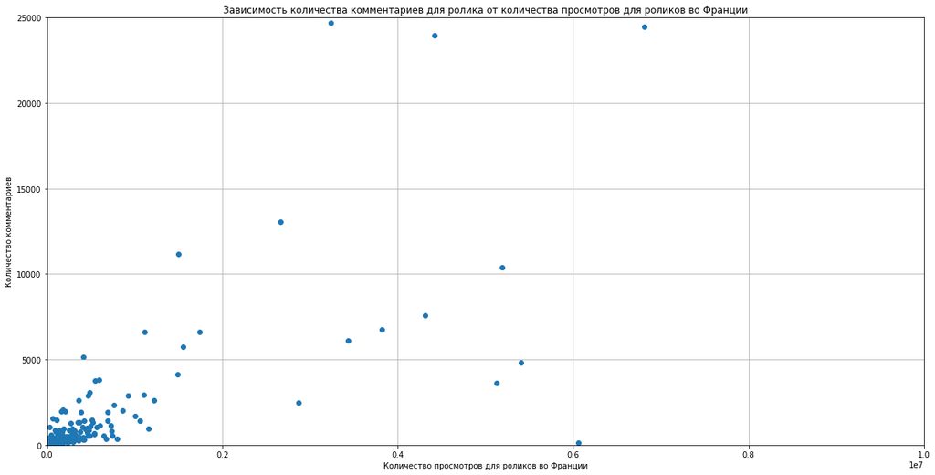

```python
plt.figure(figsize=(20,10))
plt.title('Зависимость количества комментариев для ролика от количества просмотров для роликов во Франции')
plt.ylim([0, 25000])
plt.xlim([0, 10000000])
plt.scatter(x = df_plt3['view_count'], y = df_plt3['comment_count'])
plt.ylabel('Количество комментариев')
plt.xlabel('Количество просмотров для роликов во Франции')
plt.grid(True)
plt.show()
```

**Ответ**: Линейная зависимость